# Part VII: MCMC diagnostics for bgms

Author

Maarten Marsman

Published

October 3, 2025

**Workshop Roadmap**

**You are here:**

🧭 Intro — From network psychometrics to Bayesian graphical modeling ✅  
📊 **Session I — Quantifying evidence for network edges** ✅  
🔍 **Session II — Modeling topological structure with priors** ✅  
🧠 **Session III — Comparing groups and testing network invariance** ✅  
⚙️ **Session IV — MCMC diagnostics and efficiency** 🟩

# Recap

So far in the workshop, you have learned how to:

- **Estimate and interpret** Bayesian networks within single groups,  
  assessing edge inclusion, parameter uncertainty, and posterior evidence.
- **Model structural assumptions** with different topological priors —  
  Bernoulli, Beta–Bernoulli, and Stochastic Block Models —  
  and understand how these priors shape network density and clustering.
- **Compare groups** by testing invariance and differences,  
  using Bayes factors (Savage–Dickey and model-averaged) to quantify evidence for edge and network-level effects.

## Goals for this session

We now turn to **checking the reliability of MCMC output and model adequacy**. At the end of this session, you should be able to:

- **Explain** the difference between bias reduction (warmup) and variance reduction (sampling), and how these are handled in `bgms`.
- **Compute** and **interpret** MCMC diagnostics:  
  – $\hat{R}$ for convergence,  
  – Effective sample size (ESS) for precision.
- **Compare** Metropolis vs. NUTS in terms of warmup scheme, efficiency, and diagnostics.
- **Investigate** diagnostics for selection variables (indicators and pairwise effects).

This session builds directly on your earlier skills:  
- From estimating and comparing networks → to evaluating the quality of the chains that generate those estimates.

**Recommended Reading:**

- Margossian, C., & Gelman, A. (2024). For how many iterations should we run Markov chain Monte Carlo? Preprint arXiv:2311.02726v2. doi: 10.48550/arXiv.2311.02726

**Optional Reading**

- Vehtari, A., Gelman, A., Simpson, D., Carpenter, B., & Bürkner, P.-C. (2021). Rank-normalization, folding, and localization: An improved $\hat{R}$ for assessing convergence of MCMC. *Bayesian Analysis*, *16*, 667–718. doi: 10.1214/20-BA1221

**R Setup Tip**  
Make sure to install and load the following libraries before running the examples:

```r
library(bgms)
library(ggplot2)
```

## 1. Motivation

Bayesian network analysis relies on **Markov chain Monte Carlo (MCMC)** to approximate posterior distributions.

A **Markov chain** is a stochastic process where each new state depends only on the current state.  
In **MCMC**, we use such a chain to generate dependent draws. At the start, these draws depend heavily on the initial values.

Over time, if the algorithm is well-behaved, the influence of the starting point *washes out*. The distribution of the draws settles into a stable *pattern* that no longer changes from one step to the next.

This stable long-run distribution is called the **stationary distribution**.

- For MCMC, in our case, the stationary distribution is the **posterior distribution** we want to approximate.
- *Convergence* means that the chain has reached this stationary state.
- Only after convergence can we use the draws to summarize the posterior.

Unlike direct simulation (e.g., using `rnorm` or `rbinom`), MCMC does not give independent draws from the posterior.

MCMC samples are:  
- **Dependent** — each draw is generated from the previous state of the chain.  
- **Approximate** — the chain only approaches the true posterior after some iterations.

This raises two key questions:  
1. **Convergence (bias):** Has the chain reached the stationary posterior distribution?  
2. **Precision (variance):** Have we collected enough *effectively independent* samples to summarize the posterior reliably?

In short: *Did the chain converge?* and *Do we have enough information after convergence?*

## Assignment: Match Traceplots to Posteriors

The figure below shows three traceplots (A–C) and three posterior distributions (1–3).  
Each traceplot comes from a different Markov chain, and each posterior is the distribution estimated from that chain.

**Your task:** Match each traceplot to its corresponding posterior distribution.

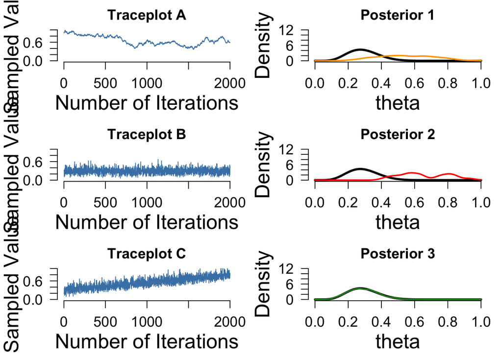

```r
set.seed(42)

# True posterior: Beta(7,17)
alpha <- 7; beta <- 17
n_draws <- 2000

# --- Chains ---
# Scenario 1: Autocorrelated + bad start
chain1 <- numeric(n_draws)
chain1[1] <- 0.9
for (i in 2:n_draws) {
  chain1[i] <- chain1[i-1] + rnorm(1, 0, 0.01)
  chain1[i] <- min(max(chain1[i], 0), 1)
}

# Scenario 2: Perfect
chain2 <- rbeta(n_draws, alpha, beta)

# Scenario 3: Drift
chain3 <- rbeta(n_draws, alpha, beta) + seq(0, 0.5, length.out=n_draws)
chain3 <- pmin(chain3, 1)

# Densities
dens1 <- density(chain1, from=0, to=1)
dens2 <- density(chain2, from=0, to=1)
dens3 <- density(chain3, from=0, to=1)

# True posterior
true_x <- seq(0, 1, length=200)
true_y <- dbeta(true_x, alpha, beta)

# Layout
layout(matrix(c(1,4,2,5,3,6), ncol=2, byrow=TRUE))
par(cex=1, mar=c(4,4,2,1))

# --- Traceplots ---
plot(chain1, type="l", col="steelblue", main="Traceplot A",
     xlab="", ylab="", axes=FALSE, ylim = c(0,1))
axis(1, cex.axis=1.2); axis(2, las=1, cex.axis=1.2)
mtext("Number of Iterations", side=1, line=2.5, cex = 1.7)
mtext("Sampled Value", side=2, line=2.5, cex = 1.7)

plot(chain2, type="l", col="steelblue", main="Traceplot B",
     xlab="", ylab="", axes=FALSE, ylim = c(0,1))
axis(1, cex.axis=1.2); axis(2, las=1, cex.axis=1.2)
mtext("Number of Iterations", side=1, line=2.5, cex = 1.7)
mtext("Sampled Value", side=2, line=2.5, cex = 1.7)

plot(chain3, type="l", col="steelblue", main="Traceplot C",
     xlab="", ylab="", axes=FALSE, ylim = c(0,1))
axis(1, cex.axis=1.2); axis(2, las=1, cex.axis=1.2)
mtext("Number of Iterations", side=1, line=2.5, cex = 1.7)
mtext("Sampled Value", side=2, line=2.5, cex = 1.7)

# --- Posterior densities ---
plot(true_x, true_y, type="l", lwd=3, col="black",
     main="Posterior 1", xlab="", ylab="", axes=FALSE, ylim=c(0,12))
lines(dens3, col="orange", lwd=2)
axis(1, cex.axis=1.2); axis(2, las=1, cex.axis=1.2)
mtext("theta", side=1, line=2.5, cex = 1.7)
mtext("Density", side=2, line=2.5, cex = 1.7)

plot(true_x, true_y, type="l", lwd=3, col="black",
     main="Posterior 2", xlab="", ylab="", axes=FALSE, ylim=c(0,12))
lines(dens1, col="red", lwd=2)
axis(1, cex.axis=1.2); axis(2, las=1, cex.axis=1.2)
mtext("theta", side=1, line=2.5, cex = 1.7)
mtext("Density", side=2, line=2.5, cex = 1.7)

plot(true_x, true_y, type="l", lwd=3, col="black",
     main="Posterior 3", xlab="", ylab="", axes=FALSE, ylim=c(0,12))
lines(dens2, col="forestgreen", lwd=2)
axis(1, cex.axis=1.2); axis(2, las=1, cex.axis=1.2)
mtext("theta", side=1, line=2.5, cex = 1.7)
mtext("Density", side=2, line=2.5, cex = 1.7)
```

**Tasks**

- **Learning Goal 1 (Warmup vs. Sampling):**  
  Which chain is **moving too slowly and still looks influenced by where it started**?
- **Learning Goal 2 (Diagnostics):**  
  Which chain shows a **systematic drift** over time, and what would $\hat{R}$ or ESS reveal about it?
- **Learning Goal 2 (Diagnostics):**  
  Which chain seems to have **settled well** into the target distribution?
- **Learning Goal 2 (Diagnostics):**  
  How do these problems show up in the **estimated posteriors** compared to the true posterior (black curve)?

**Try it**

Discuss in small groups for 5–10 minutes.  
Focus on:  
- Does the chain explore the full plausible range, or does it remain stuck or drifting?  
- Do the posterior estimates line up with the black curve (the true posterior)?  
- What consequences would these chain behaviors have for interpreting results?

**Solution**

**Traceplot B → Posterior 3:** Well-behaved chain. It explores freely and the posterior matches the truth.  
**Traceplot A → Posterior 2:** Still influenced by its starting point; slow to move. Posterior estimate biased.  
**Traceplot C → Posterior 1:** Shows systematic drift. Posterior estimate shifted away from the truth.

**Takeaway messages:**  
- A chain must both **forget its starting point** (warmup → convergence) and **move freely** around the posterior (good mixing).  
- If either condition fails, posterior inference is misleading.

### Warmup vs. Sampling

MCMC sampling has two distinct phases:

- **Warmup (burn-in):**  
  Early iterations are used to adapt the sampler and move the chain toward the stationary posterior.  
  These draws are discarded because they still reflect the starting values.
- **Sampling phase:**  
  Once adaptation has stabilized, subsequent iterations are kept for inference.
  - **Number of samples:** more samples generally mean more precise estimates.
  - **Effective sample size (ESS):** accounts for the dependence between MCMC draws.  
    ESS tells us how many independent samples would provide the same amount of information as the dependent MCMC draws.

### Diagnostics

- $\mathbf{\hat{R}}$ (potential scale reduction statistic):  
  Compares variation *within chains* to variation *between chains*.
  - $\hat{R} \approx 1$: chains have converged to the same distribution.
  - In practice, $\hat{R} < 1.01$ (Vehtari et al., 2021) is recommended as the threshold.
- **Effective sample size (ESS):**  
  A statistic that measures the *information content* of the chain.
  - Larger ESS → more reliable, precise estimates.
  - Smaller ESS → more noisy estimates.

## Assignment: Inspecting Chains in `bgms`

Let’s see how these ideas look in practice with `bgms`. We will fit a model **without edge selection** (`edge_selection = FALSE`), so the sampler only estimates parameters.

**Tasks**

- **Fit `bgm` with `edge_selection = FALSE` on the ADHD dataset.**  
  → *Learning Goal 2: Compute and interpret MCMC diagnostics for bgms output.*
- **Produce traceplots for a few parameters.**  
  → *Learning Goal 2: Visualize chain behavior and assess convergence by eye.*
- **Use the summary object to inspect** $\hat{R}$ and ESS values.  
  → *Learning Goal 2: Interpret diagnostics as measures of convergence (*$\hat{R}$) and information content (ESS).
- **Decide:**
  - Do the chains look like they have converged?  
    → *Learning Goal 1: Recognize when warmup has succeeded and chains are stationary.*
  - Do the $\hat{R}$ agree?  
    → *Learning Goal 2: Use* $\hat{R}$ as a convergence check across chains.
  - Are the effective sample sizes large or small?  
    → *Learning Goal 2: Judge the adequacy of precision via ESS.*

**Try it**

Fit a `bgm` model on the ADHD dataset with `edge_selection = FALSE`. Then:

1. Produce **traceplots** for 2–4 parameters.
2. Run `summary(fit)` and inspect the reported $\hat{R}$ and ESS values.

Use the outputs to answer these questions: - Do the traceplots suggest the chains have converged?  
- Are the $\hat{R}$ values close to 1?  
- Are the effective sample sizes large enough to trust the estimates?

Here is some example code to scaffold your work:

```r
library(bgms)

# Fit model without edge selection
fit = bgm(ADHD, edge_selection = FALSE)

# Inspect convergence diagnostics
summary(fit)

# Traceplots for some parameters
main_samples = do.call(rbind, fit$raw_samples$main)
colnames(main_samples) = fit$raw_samples$parameter_names$main
pairwise_samples = do.call(rbind, fit$raw_samples$pairwise)
colnames(pairwise_samples) = fit$raw_samples$parameter_names$pairwise

plot(pairwise_samples[, 1], type = "l")
```

**Solution**

- **Traceplots**  
  Well-behaved chains should look like “fat hairy caterpillars” that wander freely across the posterior range.  
  If chains stay stuck, drift over time, or show very different ranges, that suggests non-convergence.
- $\hat{R}$ values  
  Numbers very close to 1 (typically < 1.01) indicate that the chains are sampling from the same distribution.  
  If $\hat{R}$ is noticeably larger than 1, convergence is doubtful.
- **Effective sample sizes (ESS)**  
  Larger ESS means more information and smaller Monte Carlo error.  
  Small ESS indicates the estimates are less precise and may not be trustworthy.

**Takeaway:**  
- Warmup reduces **bias**.  
- The number of samples controls **precision**.  
- ESS tells us how informative those samples actually are.  
- $\hat{R}$ tells us whether chains have converged.

### What if diagnostics are not satisfactory?

- **If** $\hat{R}$ is larger than 1.01  
  → Chains have not mixed to the same distribution.
  - Increase the number of iterations.
  - Run more chains with dispersed starting values.
  - Consider switching to a more efficient sampler (e.g. NUTS instead of Metropolis).
- **If ESS is small**  
  → The effective number of independent samples is too low for precise inference.
  - Increase the number of iterations.
  - Reduce autocorrelation by using a more efficient sampler.

## 2. MCMC Workflow & Control Parameters

Every MCMC run follows a **workflow**:  
1. **Initialization** – set starting values for each chain.  
2. **Warmup (burn-in)** – adapt tuning parameters and move the chain toward the stationary posterior (draws are discarded).  
3. **Sampling** – collect draws for inference once adaptation has finished.  
4. **Diagnostics** – evaluate convergence ($\hat{R}$) and precision (ESS).

How this workflow is carried out depends on the **control parameters** we choose:  
- number of chains,  
- number of iterations,  
- length of warmup,  
- and the type of update method (e.g., Metropolis or NUTS).

### Stan-style Warmup Schedule in `bgms` for HMC and NUTS methods

Warmup for HMC/NUTS in `bgms` is structured into **stages**:

1. **Stage 1 – Fast adaptation (~7.5% of warmup)**
   - Adapt the step size quickly so the sampler begins to explore.
2. **Stage 2 – Adaptive windows**
   - Build doubling “windows” of increasing length (25, 50, …).
   - Within each window:
     - (Optional) Update the **mass matrix** to match posterior curvature.
     - Refine the step size using dual averaging.
3. **Stage 3a – Final stabilization (~last 10%)**
   - Stabilize the step size.
   - Lock in the final mass matrix if estimated.
4. **Stage 3b – Edge selection adaptation (if enabled)**
   - Adapt the **proposal standard deviations** for Metropolis edge moves.
5. **Stage 3c – Final adjustments (if enabled)**
   - Make final adjustments of the global step size after edge adaptation.

After these stages, **warmup ends** and the sampler enters the **sampling phase**.

### Warmup for Metropolis (Random Walk proposals) in `bgms`

In `bgms`, warmup for Metropolis-within-Gibbs is much simpler than for NUTS:

- **Adaptation goal:** learn suitable proposal standard deviations (step sizes) for the random walk updates.
- **How:** use a Robbins–Monro adaptation scheme.
  - After each iteration, acceptance probabilities are used to adjust proposal scales.
  - The update is weighted by a decaying factor (∝ iteration^(-0.75)) so adaptation gradually stabilizes.
  - Target acceptance rate is around 0.44 (standard for one-dimensional random walks).
- **End of warmup:** once the proposal scales have adapted, the sampler fixes them and begins the sampling phase.

**Key difference from warmup for NUTS:**  
- NUTS warmup involves multiple stages (step size tuning, mass matrix adaptation, final stabilization).  
- Metropolis warmup is a single-stage process focused only on proposal standard deviations.

In both cases, **warmup draws are discarded** because they reflect adaptation rather than stationary sampling.

## Assignment: Relative efficiency MCMC procedures

We now examine how these choices **show up in diagnostics**. The next exercises compare samplers and control parameters in terms of $\hat{R}$ (convergence) and ESS (information).

**Goal:** With a short run, Metropolis may not reach satisfactory diagnostics, while NUTS often does.

**Tasks**

- **Fit the ADHD model twice (`edge_selection = FALSE`):**
1. `update_method = "metropolis"`,
2. `update_method = "nuts"`.  
   → *Learning Goal 3: Compare samplers (Metropolis vs. NUTS).*
- **Inspect diagnostics:** compare $\hat{R}$ and ESS in the summaries.  
  → *Learning Goal 2: Compute and interpret MCMC diagnostics.*
- **Traceplots:** make traceplots for 2–4 parameters.  
  → *Learning Goal 2: Use visual checks to assess convergence.*
- **Decide:**
  - Do the chains look converged?  
    → *Learning Goal 1: Recognize when chains are stationary (post-warmup).*
  - Are the $\hat{R}$ values close to 1 for both samplers?  
    → *Learning Goal 2: Interpret* $\hat{R}$ as a convergence check.
  - Which sampler yields larger ESS for the same number of iterations?  
    → *Learning Goal 3: Assess relative efficiency in terms of ESS per iteration.*

**Try it**

1. Fit the model once with **Metropolis** and once with **NUTS** (`edge_selection = FALSE`).
2. Call `summary(fit)` for each run and compare the reported $\hat{R}$ and ESS values.
3. Produce traceplots for 2–4 parameters.

Use these outputs to answer:  
- Do the chains appear to have converged?  
- Are the $\hat{R}$ values close to 1 for both samplers?  
- Which sampler provides larger ESS for the same number of iterations?

```r
library(bgms)

fit_met <- bgm(ADHD,
               update_method   = "adaptive-metropolis",
               edge_selection  = FALSE,
               iter = 1000,
               seed = 4321)

fit_nuts <- bgm(ADHD,
                update_method   = "nuts",
                edge_selection  = FALSE,
                seed = 4321)

summary(fit_met)
summary(fit_nuts)
```

**Solution**

- **Traceplots**
  - Metropolis chains often move slowly at 1,000 iterations and may not explore the full posterior range.
  - NUTS chains typically mix more quickly and cover the posterior more efficiently.
- $\hat{R}$
  - For NUTS, values are usually close to 1.
  - For Metropolis, some parameters may have $\hat{R} > 1.01$, indicating incomplete convergence.
- **ESS**
  - NUTS generally achieves a larger ESS at the same number of iterations.
  - Metropolis requires more iterations to reach comparable ESS.

**Takeaway message**  
With short runs, NUTS is usually more efficient, showing better convergence ($\hat{R}$) and higher information content (ESS).  
Metropolis can still reach satisfactory diagnostics, but only with longer chains or more careful control parameters.

## Assignment B: Improving Metropolis via control parameters

In the previous exercise, we saw that Metropolis underperformed at 1,000 iterations.  
The goal here is to show that Metropolis diagnostics improve when we **increase the number of iterations and/or the number of chains**.

**Tasks**

Building on the previous exercise (where Metropolis underperformed at 1,000 iterations), now examine how diagnostics improve when we adjust control parameters:

- **Refit with Metropolis only** (`edge_selection = FALSE`).  
  → *Learning Goal 3: Compare samplers and understand when extra sampling is needed.*
- **Increase iterations** (e.g., from 1,000 → 4,000 or 8,000). Optionally **increase chains** (e.g., 4 → 6).  
  → *Learning Goal 1: Recognize how sampling length and number of chains affect convergence and precision.*
- **Inspect diagnostics:** compare $\hat{R}$ and ESS across runs.  
  → *Learning Goal 2: Interpret convergence and precision statistics in practice.*
- **Traceplots:** check whether the chains now look stable and overlapping.  
  → *Learning Goal 2: Use visual checks alongside numerical diagnostics.*
- **Decide:**
  - Does $\hat{R}$ approach 1 as iterations (and/or chains) increase?
  - Does ESS increase with more iterations?
  - At what settings do diagnostics become satisfactory?  
    → *Learning Goal 1 + 2: Link diagnostic outcomes directly to control parameter choices.*

**Try it**

In the previous exercise, Metropolis did not perform well at 1,000 iterations.  
Now rerun the model with **Metropolis only** and adjust the control parameters:

1. Increase the number of iterations (e.g., from 1,000 → 2,000 or 10,000).
2. Optionally increase the number of chains (e.g., from 4 → 8).
3. Inspect the $\hat{R}$ and ESS values in the summaries.

Reflect on:  
- Does $\hat{R}$ move closer to 1 as iterations and/or chains increase?  
- Does ESS grow with longer runs?  
- At what settings would you consider the diagnostics satisfactory?

```r
# Metropolis: longer chains
fit_met_more_iter <- bgm(ADHD,
                         update_method = "adaptive-metropolis",
                         edge_selection = FALSE,
                         chains = 4,
                         iter = 2000,
                         seed = 4321)


# Metropolis: more chains
fit_met_more_chains <- bgm(ADHD,
                           update_method = "adaptive-metropolis",
                           edge_selection = FALSE,
                           chains = 8,
                           iter = 1000,
                           seed = 4321)


summary(fit_met_more_iter)
summary(fit_met_more_chains)
```

**Solution**

- $\hat{R}$  
  Moves closer to 1 as the number of iterations increases and when more chains are added.
- **ESS**  
  Grows with longer runs; more iterations generally produce larger ESS values.
- **Traceplots**  
  With more iterations, chains tend to overlap and appear stationary, indicating improved mixing.

**Takeaway message**  
Metropolis can achieve satisfactory diagnostics when control parameters are scaled appropriately.  
Increasing iterations (and, when useful, chains) improves $\hat{R}$ and ESS, allowing Metropolis to approach the reliability of NUTS given sufficient sampling.

### From general diagnostics to variable selection

So far, we have studied MCMC diagnostics in general:  
- Traceplots as a visual tool,  
- $\hat{R}$ for convergence,  
- ESS as a measure of information in dependent draws.

But in `bgms`, our main interest is usually in **edge selection**:  
- **Binary indicators** for edge inclusion/exclusion,  
- **Spike–and–slab parameters**, e.g., the pairwise interactions, or their group differences, that are being selected by the indicators.

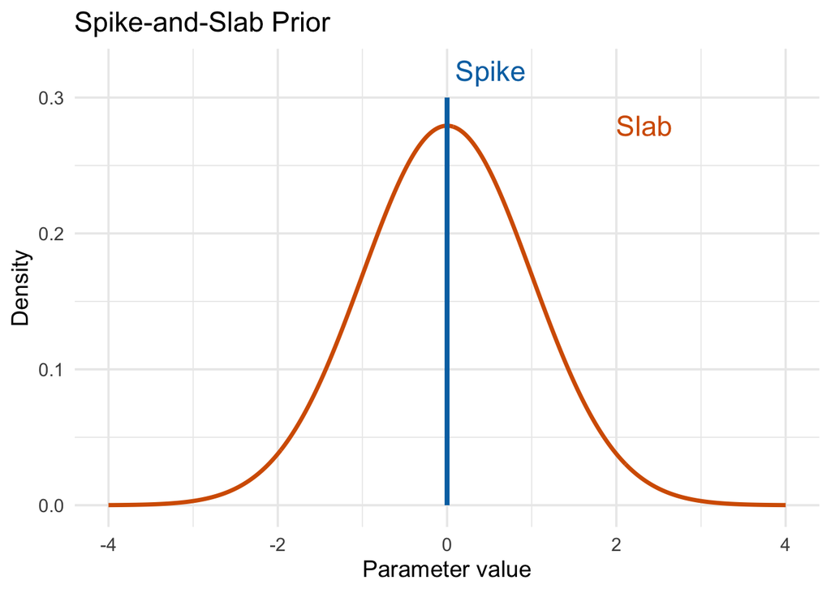

```r
library(ggplot2)

# Parameters
p <- 0.7   # inclusion probability (weight on slab)

# Grid
x <- seq(-4, 4, length.out = 500)

# Slab density scaled by p
slab <- p * dnorm(x, mean = 0, sd = 1)

# Data for slab
df_slab <- data.frame(x = x, density = slab)

# Data for spike
df_spike <- data.frame(x = 0, xend = 0, y = 0, yend = 1 - p)

# Plot
ggplot(df_slab, aes(x = x, y = density)) +
  geom_line(color = "#D55E00", linewidth = 1.2) +
  geom_segment(data = df_spike,
               aes(x = x, xend = xend, y = y, yend = yend),
               inherit.aes = FALSE,
               color = "#0072B2", linewidth = 1.4, lineend = "butt") +
  labs(x = "Parameter value", y = "Density",
       title = "Spike-and-Slab Prior") +
  annotate("text", x = 0.1, y = 1 - p + 0.02, label = "Spike", color = "#0072B2", hjust = 0, size =6) +
  annotate("text", x = 2, y = max(slab), label = "Slab", color = "#D55E00", hjust = 0,size=6) +
  theme_minimal(base_size = 14)
```

To evaluate MCMC samples of them properly, we need to understand how $\hat{R}$ and ESS apply in this setting, and how we can derive effective sample sizes for these discrete or mixture-valued parameters.

## 3. Diagnostics for Variable Selection Parameters

So far, we have treated ESS and $\hat{R}$ in general.  
In `bgms`, however, we care about **variable selection parameters**:

- **Indicators** behave like a two-state Markov chain.
  - The chain can get “stuck” in 0 or 1 for long stretches.
  - This produces **high autocorrelation** $\Rightarrow$ low ESS.
- **Spike–and–slab parameters** are a mixture of a point mass (spike at zero when not selected) and a continuous slab (a density when selected).
  - Switching between spike and slab creates additional autocorrelation.
  - ESS can therefore often be low for these parameters as well.
- **Takeaway:** Even when $\hat{R} \approx 1$, ESS for variable selection parameters can be modest. This affects the *precision* of reported edge inclusion probabilities.

### ESS for binary indicators

**Closed-form ESS for binary indicators**

For a binary indicator $\gamma_t$, modelled as a two-state Markov chain with transition probabilities $\hat{a} = \Pr(0 \to 1)$ and $\hat{b} = \Pr(1 \to 0)$:

- Lag-1 autocorrelation: $\rho_1 = 1 - (\hat{a}+\hat{b})$.
- Autocorrelations decay geometrically: $\rho_k = \rho_1^k$.
- Integrated autocorrelation time:
  $$\tau_{\text{int}} = \frac{2 - (\hat{a}+\hat{b})}{\hat{a}+\hat{b}} .$$
- Effective sample size:
  $$\mathrm{ESS}(\gamma) = \frac{T}{\tau_{\text{int}}}.$$

### ESS for spike–and–slab parameters

**Delta method derivation for $\hat{\theta} = \hat{p}\cdot\hat{\mu}$**

- Let $\hat{p}$ = posterior inclusion probability (from the indicator chain).
- Let $\hat{\mu}$ = conditional mean given inclusion.
- Our estimator of the marginal mean is
  $$\hat{\theta} = \hat{p}\,\hat{\mu}.$$

By the delta method, treating $\hat{p}$ and $\hat{\mu}$ as approximately uncorrelated:

$$\operatorname{Var}(\hat{\theta})
\approx \hat{\mu}^2 \,\operatorname{Var}(\hat{p})
+ \hat{p}^2 \,\operatorname{Var}(\hat{\mu}).$$

Thus the Monte Carlo standard error is

$$\text{MCSE}(\hat{\theta}) =
\sqrt{\hat{\mu}^2\,\text{MCSE}^2(\hat{p}) +
\hat{p}^2\,\text{MCSE}^2(\hat{\mu})}.$$

Finally, since
$$\text{MCSE}^2 = \frac{\text{Posterior Variance}}{\text{ESS}},$$
we can solve for an **effective sample size for $\hat{\theta}$**:

$$\text{ESS}_{\text{combined}} =
\frac{\operatorname{Var}(\theta)}{\operatorname{Var}(\hat{\theta})}.$$

## Assignment: Investigate $\hat{R}$ and ESS for Selection Variables

We now analyze the ADHD dataset **with edge selection** using `update_method = "nuts"`. The goal is to compare diagnostics for **binary indicators** and **spike–and–slab parameters** (i.e., the pairwise interactions).

**Tasks**

- **Fit** a `bgm` model on the ADHD dataset with  
  `update_method = "nuts"` and `edge_selection = TRUE` (run multiple chains).  
  → *Learning Goal 3: Apply samplers with edge selection enabled.*
- **Inspect the summary** for several edges:
  - Compare diagnostics ($\hat{R}$, ESS) for the **binary indicators** (edge inclusion), and the corresponding **spike–and–slab parameters** (pairwise interactions).
  - Note their posterior means.  
    → *Learning Goal 2: Compute and interpret diagnostics in practice.*
- **Visualize chain behavior** with traceplots for the same edges.  
  → *Learning Goal 2: Use visual checks to complement numerical diagnostics.*
- **Compare across parameter types:**
  - Are $\hat{R}$ values acceptable for both indicators and slabs?
  - Are ESS values systematically lower for indicators and spike–and–slab parameters than for other continuous parameters?
  - How do these diagnostics compare with the ESS values you obtained earlier **without selection**?  
    → *Learning Goal 1 & 2: Connect diagnostics to the reliability of posterior summaries.*

**Try it**

1. Fit `bgm` with `update_method = "nuts"` and `edge_selection = TRUE` (e.g., `chains = 4`, a few thousand iterations).
2. Pull the two diagnostics tables:
   - `summary(fit)$indicator` → **Indicators** (edge inclusion).
   - `summary(fit)$pairwise` → **Pairwise effects** (interaction parameters).
3. Pick 3–5 **matched edges** (same edge in both tables). Include
   - at least one edge with inclusion ≈ 0 or ≈ 1 (to see constant indicators/NA diagnostics), and
   - at least one edge with inclusion in the middle (e.g., 0.2–0.8) to see switching.
4. Compare the diagnostics columns for those edges:
   - `Rhat`, `n_eff` (ESS), and `mcse` (if reported).
5. Make **traceplots** for the same edges (both the indicator and the pairwise effect) and relate the plots to the numbers.

**Guiding questions** - Which edges have the **lowest ESS** for **indicators**? For **pairwise effects**?  
- Do the traceplots explain the ESS values (e.g., slow switching for pairwise effects)?  
- Are the **$\hat{R}$** values acceptable (≈ 1), even when ESS is modest?  
- Do any indicators show **constant 0 or 1** (hence NA diagnostics)? How does that relate to their pairwise effects?  
- How do these diagnostics compare to your earlier run **without selection**?

```r
library(bgms)
#no selection
fit_nosel = bgm(ADHD,
                update_method = "nuts",
                edge_selection = FALSE,
                chains = 4,
                iter = 1000,
                seed = 2025)
#selection
fit_sel = bgm(ADHD,
              update_method = "nuts",
              edge_selection = TRUE,
              chains = 4,
              iter = 1000,
              seed = 2025)

#summaries pairwise effects
summary(fit_nosel)$pairwise
summary(fit_sel)$pairwise

#summaries indicators
summary(fit_sel)$indicator
```

**Solution**

- **$\hat{R}$:** With NUTS and sufficient iterations, $\hat{R} \approx 1$ for both indicators and pairwise effects, showing convergence across chains.
- **ESS:**
  - Indicators can show **lower ESS** because they are two–state variables and the chain can dwell in 0 or 1 for long stretches.
  - Pairwise effects also can have **modest ESS**, reflecting the slow switching between spike and slab.
  - Continuous parameters such as thresholds usually achieve much higher ESS under the same run.
- **Traceplots:**
  - Pairwise effects also show sequences of exact zeros whenever the indicator is 0, and continuous variation (slab values) when the indicator is 1.

**Takeaway**  
Even with an efficient sampler (NUTS) and acceptable $\hat{R}$, **ESS for indicators and pairwise effects can be modest**.  
When interpreting results, always check MCSE alongside $\hat{R}$ and ESS, and if precision is insufficient, increase iterations or chains.

### Closing

A key feature of `bgms` is that it reports $\hat{R}$ and ESS not only for continuous parameters,  
but also for **selection variables** (indicators and pairwise effects).

As far as we know, this is the only implementation that provides full diagnostics  
for these discrete and mixture-valued parameters. This makes it possible to:

- Evaluate convergence and mixing of selection variables,
- Quantify how much effective information underlies edge inclusion probabilities,
- Compare diagnostics across indicators, pairwise effects, and continuous parameters.

### Take-home message

This completes the **Bayesian workflow** for network models:

1. **Estimate** the model.
2. **Diagnose** the chains — check $\hat{R}$, ESS, and MCSE for all parameters,  
   including indicators and pairwise effects.
3. **Interpret** results once diagnostics confirm reliability.

Diagnostics complete the Bayesian workflow: results should only be interpreted once the chains are shown to be reliable.